# Generalized Linear Models

Melissa Guzman

March 16, 2016

Etherpad:

https://public.etherpad-mozilla.org/p/404GLMs

Link to all material:

https://github.com/lmguzman/GLMs

## What is a frequency distribution?

## What frequency distributions can you remember?

# Frequency Distributions

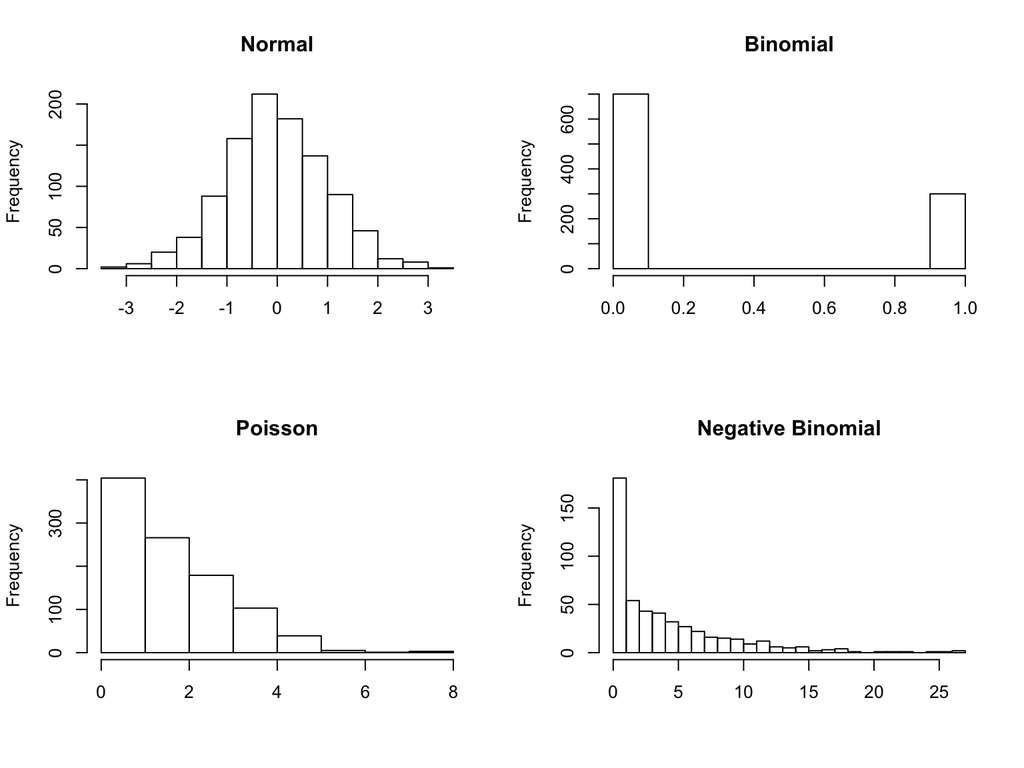

# Why do we care?

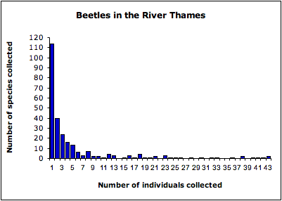

Relative species abundance of beetles sampled from the river Thames collected by C.B. Williams (1964). (Magurran 2004)

# Learning Objectives

By the end of this lesson the students will:

- Differentiate and categorize GLMs vs ANOVAS and regressions
- Identify the different components of GLMs
- Select the most appropriate GLM
- Carry out a GLM

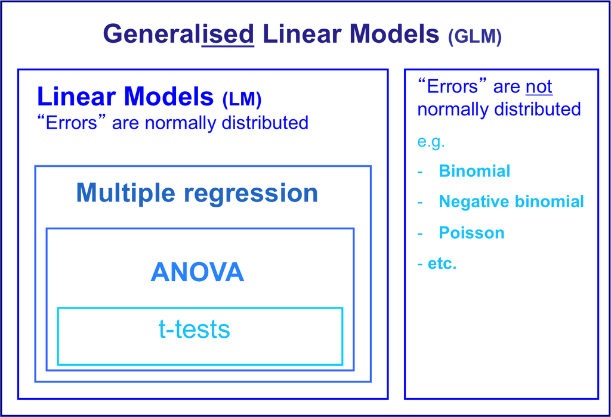

## LO: Differentiate and categorize GLMs vs ANOVAS and regressions

# When do we use them?

Used when the *residuals* from a linear model are not-normal

Whilst it is the error distribution (the residuals) that is important, the distribution of the dependent variable has a strong influence on this.

# General formula

$y = g(\beta_{0} + \beta_{1}X_{1} + \beta_{2}X_{2} + ... + \beta_{i}X_{i}) + \varepsilon$

$X$ are your explanatory variables

$y$ your response variable

$\beta$ are the coefficients

$\varepsilon$ is the error term

Where $g$ is a function (called the link function) which transforms each value of y in relation to the linear predictors (the variables and their coefficients) i.e. the link function transforms the dependent variable within the model.

## LO: Identify the different components of GLMs

# What is the link function?

Link Functions: defining the shape of the relationship between the dependent & independent variables.

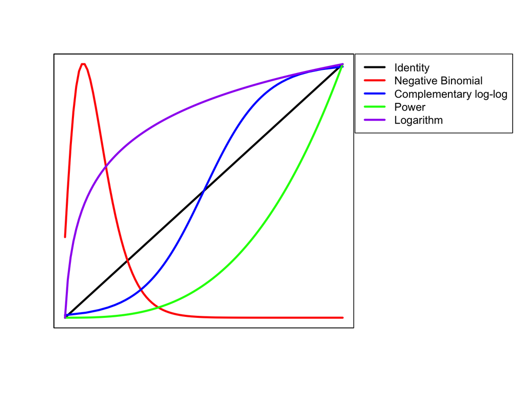

# Why use a link function instead of transforming the data?

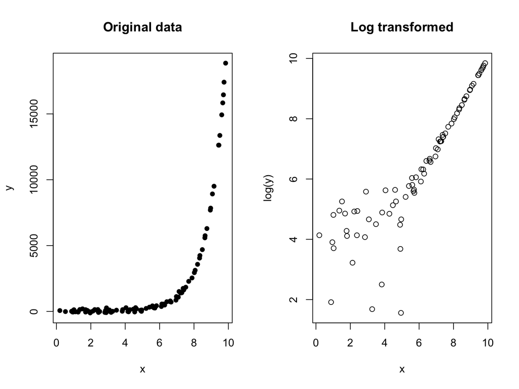

# Let’s fit some models to that data

```r
model1 <- lm(log(y)~x)
model2 <- glm(y~x, family = gaussian (link = "log"), start=c(1, 1))
```

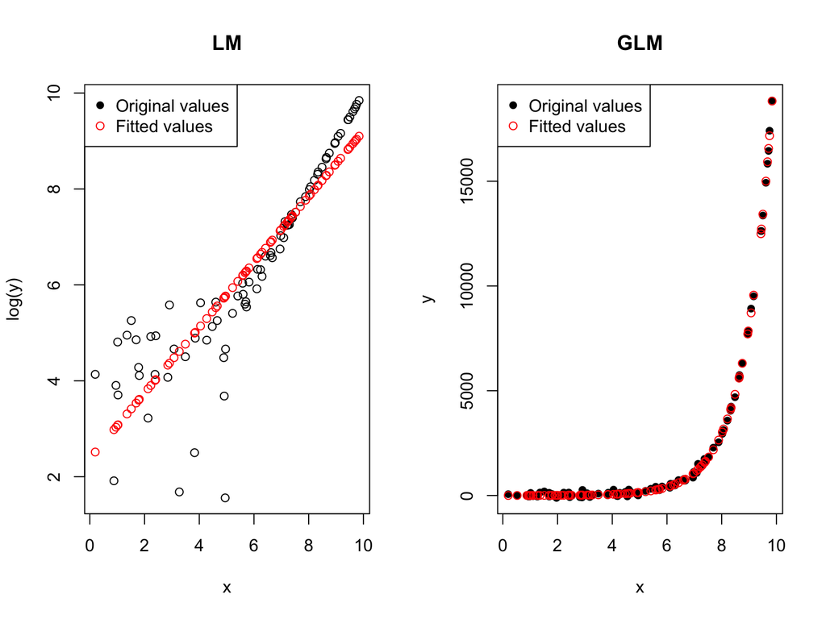

Using a link function is often better than simply transforming the dependent variable, because it doesn’t simply attempt to make the variance constant. Instead, it fits a function that “adjusts” the variance as the data is being fitted.

# What links should I use?

| Families | Links |
| --- | --- |
| gaussian (c) | identity, log, inverse |
| inverse.gaussian (c) | $1/\mu^2$, inverse, identity, log |
| gamma (c) | inverse, identity, log |
| quasi (c) | logit, probit, cloglog, identity, inverse, $1/\mu^2$, sqrt, power |
| poisson (d) | log, identity, sqrt |
| quasipoisson (d) | identity, logit, probit cloglog |
| negative binomial (d) | log, sqrt, identity *use glm.nb function from MASS library* |
| binomial (d) | logit, probit, cauchit, log, cloglog |
| quasibinomial (d) | identity, logit, probit, cloglog |

d = discrete, c = continous

First link is the default

# So many options… How do I choose?

Start with the default link function for the family error term that you have chosen. E.g. for family = binomial, the “logit” is the default link function.

The “correct” combination of family and link function is arrived at by trial and error, comparing

- residual distributions (aiming for normal)
- adjusted R2 values (where relevant, higher is better)
- AIC values (lower is better) of different nested models

## LO: Select the most appropriate GLM

# Challenge

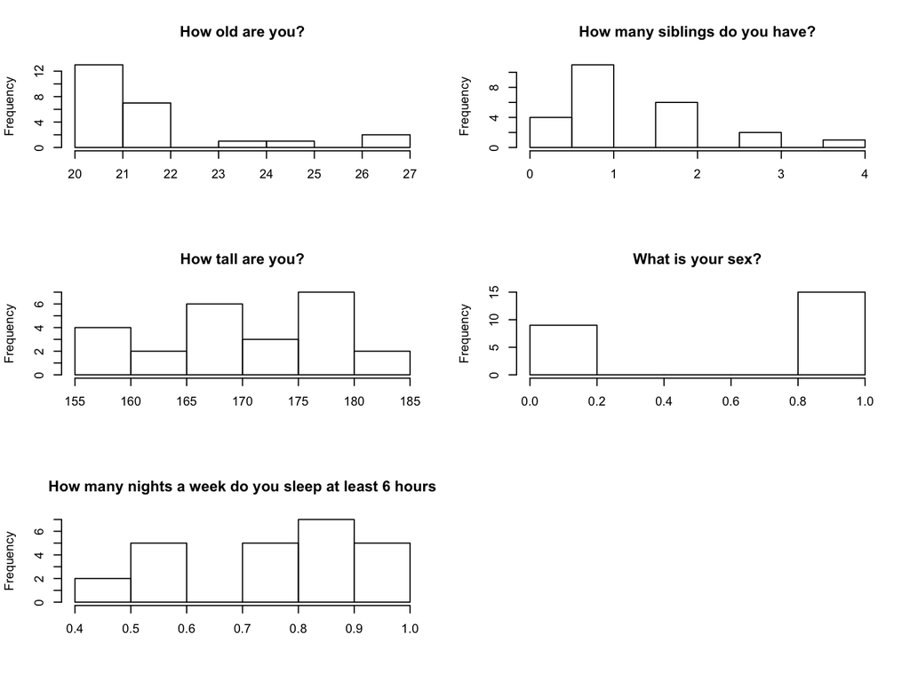

What type of distribution are these?

Can you think of other types of data with the same distribution?

What family and link functions would you use?

# How do I do it in R?

Let’s look at some data first.

```r
Lizards <- read.csv('Data/lizards.txt', sep = "\t")
head(Lizards)
```

```
##    n   sun height  perch    time  species
## 1 20 Shade   High  Broad Morning opalinus
## 2 13 Shade    Low  Broad Morning opalinus
## 3  8 Shade   High Narrow Morning opalinus
## 4  6 Shade    Low Narrow Morning opalinus
## 5 34   Sun   High  Broad Morning opalinus
## 6 31   Sun    Low  Broad Morning opalinus
```

## LO: Carry out a GLM

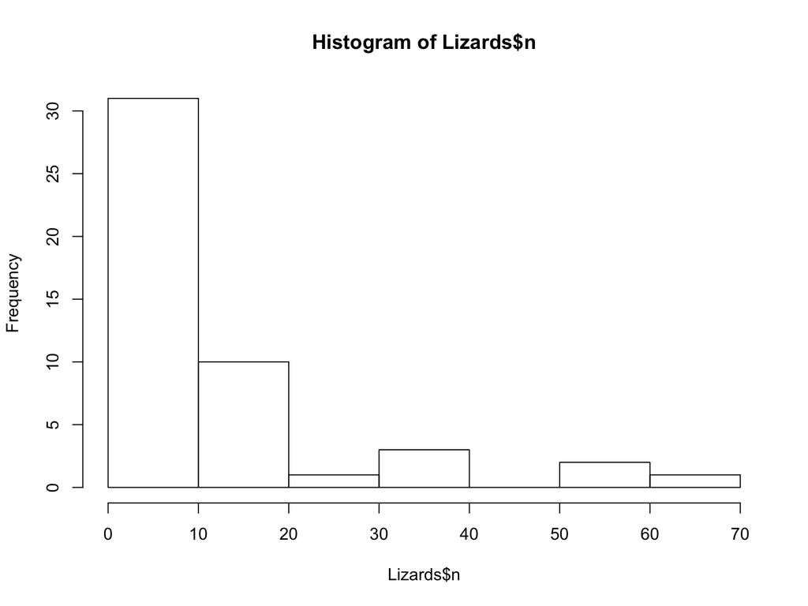

```r
hist(Lizards$n)
```

```r
LizardsModelLM <- lm(n ~ sun + height + species, data = Lizards)

LizardsModel <- glm(n ~ sun + height + species, family = poisson (link = log), data = Lizards)
```

# Check assumptions of the model

1. Distribution of the residuals

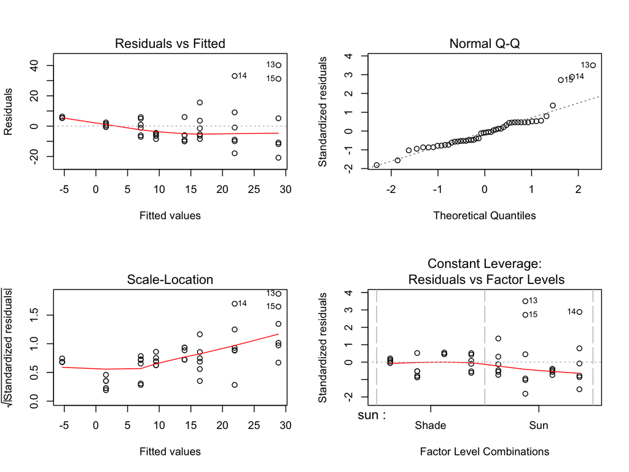

```r
par(mfrow = c(2,2))
plot(LizardsModelLM)
```

# Let’s see the GLM

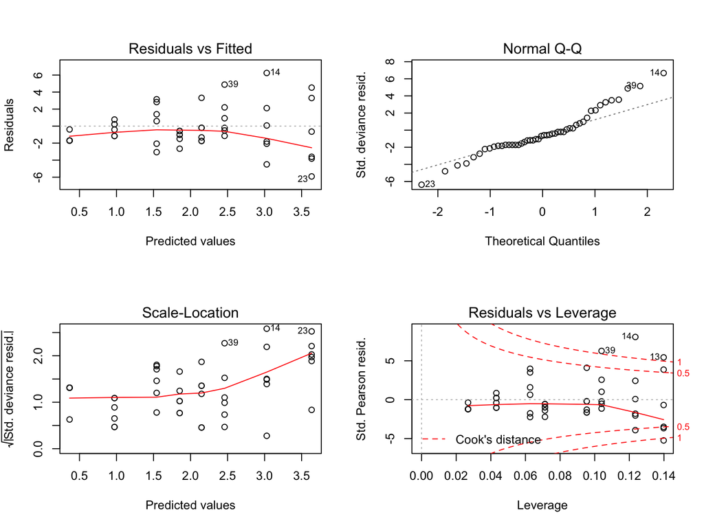

```r
par(mfrow = c(2,2))
plot(LizardsModel)
```

2. Overdispersion

In a poisson distribution, mean = variance

Overdispersion parameter $\theta$ = $\frac{ \text{residual deviance}}{\text{residual degrees of freedom}}$

```r
LizardsModel$deviance / LizardsModel$df.residual
```

```
## [1] 6.352926
```

If your model is overdispersed use the *quasi* family. In this case, quasipoisson

# pseudo $R^2$ explained deviance

Pseudo $R^2$ = $\frac{\text{null deviance} - \text{residual deviance}}{\text{null deviance}}$

```r
(LizardsModel$null.deviance - LizardsModel$deviance) / LizardsModel$null.deviance
```

```
## [1] 0.6210064
```

# Model Summary

```r
summary(LizardsModel)
```

```
##
## Call:
## glm(formula = n ~ sun + height + species, family = poisson(link = log),
##     data = Lizards)
##
## Deviance Residuals:
##     Min       1Q   Median       3Q      Max
## -5.9107  -1.6984  -0.6075   0.6341   6.2438
##
## Coefficients:
##                 Estimate Std. Error z value Pr(>|z|)
## (Intercept)      0.97277    0.12778   7.613 2.68e-14 ***
## sunSun           1.48684    0.10858  13.694  < 2e-16 ***
## heightLow       -0.60659    0.08812  -6.884 5.83e-12 ***
## speciesopalinus  1.17576    0.09919  11.853  < 2e-16 ***
## ---
## Signif. codes:  0 '***' 0.001 '**' 0.01 '*' 0.05 '.' 0.1 ' ' 1
##
## (Dispersion parameter for poisson family taken to be 1)
##
##     Null deviance: 737.56  on 47  degrees of freedom
## Residual deviance: 279.53  on 44  degrees of freedom
## AIC: 450.78
##
## Number of Fisher Scoring iterations: 5
```

# Challenge

Using the Boar csv, run the appropriate GLM.

Make sure you check the model assumptions and all appropriate link functions

# Learning Objectives

By the end of this lesson the students will:

- Differentiate and categorize GLMs vs ANOVAS and regressions
- Identify the different components of GLMs
- Select the most appropriate GLM
- Carry out a GLM

# Summary

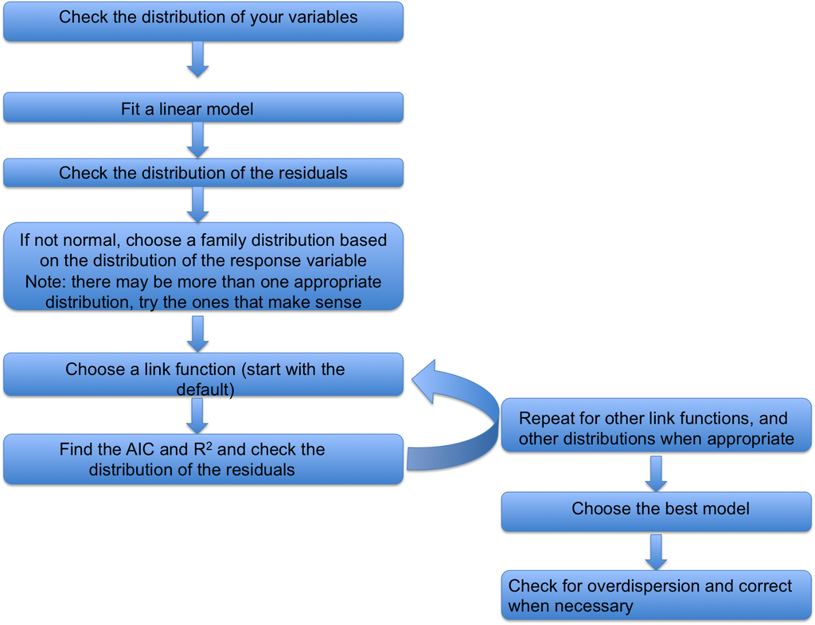

# Challenge 2 Solution

Look at the data first

```r
Boar <- read.csv('Data/Boar.csv')

head(Boar)
```

```
##   Tb sex age length
## 1  0   1   1   46.5
## 2  0   2   1   47.0
## 3  0   1   1   48.0
## 4  0   1   1   51.5
## 5  0   2   1   53.0
## 6  0   2   1   53.0
```

Tb is the response variable. Sex, age and length are explanatory variables.

```r
summary(Boar)
```

```
##        Tb              sex             age            length
##  Min.   :0.0000   Min.   :1.000   Min.   :1.000   Min.   : 46.5
##  1st Qu.:0.0000   1st Qu.:1.000   1st Qu.:3.000   1st Qu.:106.0
##  Median :0.0000   Median :2.000   Median :3.000   Median :121.0
##  Mean   :0.4758   Mean   :1.582   Mean   :3.142   Mean   :116.8
##  3rd Qu.:1.0000   3rd Qu.:2.000   3rd Qu.:4.000   3rd Qu.:129.5
##  Max.   :1.0000   Max.   :2.000   Max.   :4.000   Max.   :165.0
##  NA's   :58       NA's   :35      NA's   :7       NA's   :110
```

Let’s check the distribion to see how it looks like.

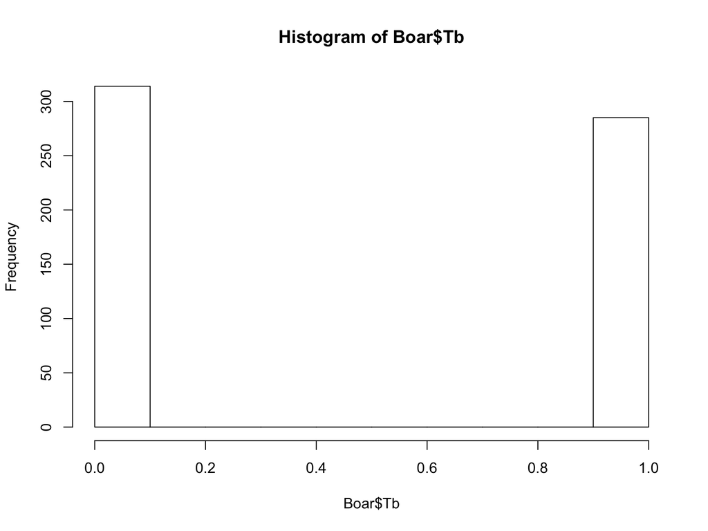

```r
hist(Boar$Tb)
```

Looking at the summary and histogram, Tb is a categorical variables with two categories. Therefore we need to use the binomial distribution.

We can start with a linear model

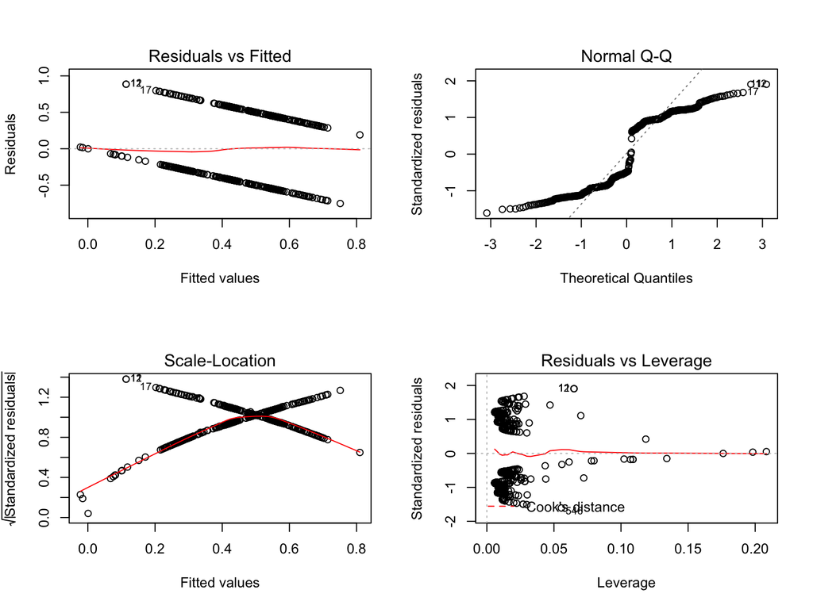

```r
LinearBoarModel <- lm(Tb ~ sex * age * length, data = Boar)
par(mfrow = c(2,2))
plot(LinearBoarModel)
```

The residuals don’t look very normally distributed. Let’s use a binomial family.

The default link functions for the binomial distribution are: logit, probit, cauchit, log, cloglog Let’s start with the logit function

```r
LogitBoarModel <- glm(Tb ~ sex * age * length, family = binomial (link = logit), data = Boar)
```

Let’s look at the AIC and pseudo $R^2$

```r
AIC(LogitBoarModel)
```

```
## [1] 653.3006
```

```r
(LogitBoarModel$null.deviance - LogitBoarModel$deviance) / LogitBoarModel$null.deviance
```

```
## [1] 0.06451869
```

And the distribution of the residuals

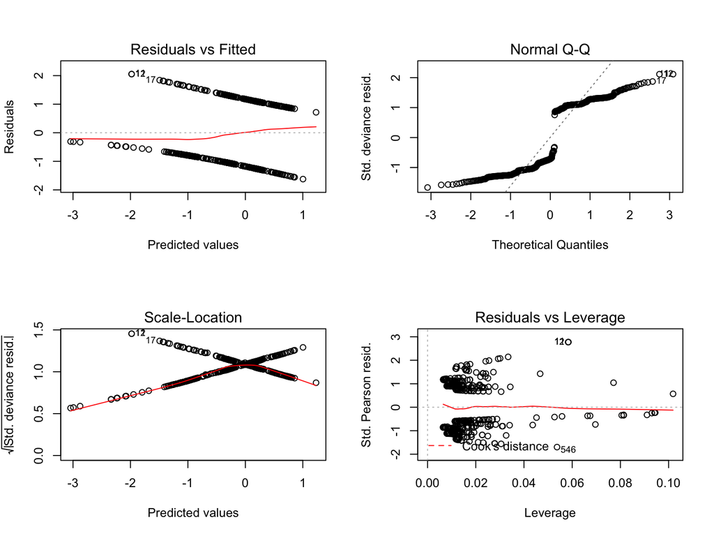

```r
par(mfrow = c(2,2))
plot(LogitBoarModel)
```

Look at all the other link functions and choose the one with the lowest AIC and better distribution of the residuals.

```r
probitBoarModel <- glm(Tb ~ sex * age * length, family = binomial (link = probit), data = Boar)

cauchitBoarModel <- glm(Tb ~ sex * age * length, family = binomial (link = cauchit), data = Boar)

logBoarModel <- glm(Tb ~ sex * age * length, family = binomial (link = log), data = Boar)

cloglogBoarModel <- glm(Tb ~ sex * age * length, family = binomial (link = cloglog), data = Boar)

AIC(LogitBoarModel, probitBoarModel, cauchitBoarModel, logBoarModel, cloglogBoarModel)
```

```
##                  df      AIC
## LogitBoarModel    8 653.3006
## probitBoarModel   8 653.3818
## cauchitBoarModel  8 652.2948
## logBoarModel      8 652.8498
## cloglogBoarModel  8 653.1425
```

Let’s check the distribution of the residuals.

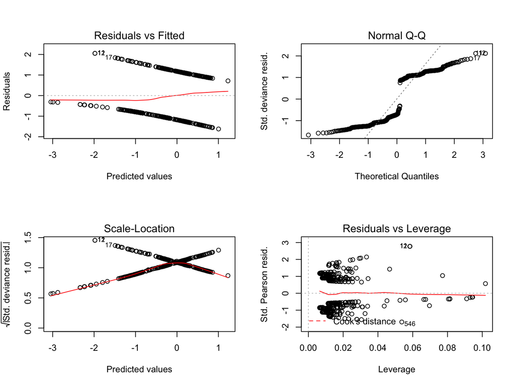

```r
par(mfrow = c(2,2))
plot(LogitBoarModel)
```

We also need to check for overdispersion

```r
LogitBoarModel$deviance / LogitBoarModel$df.residual
```

```
## [1] 1.311318
```

$\theta$ is close to 1, so we can keep the binomial family.

We can keep refining the model using model simplification to choose a model we are happy with.